# Performing age estimation on C. elegans with `wormAge`

Romain Bulteau

April 24, 2019

This document showcases how to use the `wormAge` package to perform age estimates on *C. elegans* gene expression data.

```r
library(wormAge)
# Bioconductor packages
library(GEOquery)
library(biomaRt)
```

# Getting data

We’ll be fetching some GEO datasets for this and time series are good examples since we can easily check if the estimates are correct. Let’s load GSE52861, a dataset from Hendriks et al. (2014).

### Gene expression data

```r
temp <- tempfile() # make a temporary file for the data

# The data we want is the raw counts in the supplementary files of this dataset
download.file(
  "https://www.ncbi.nlm.nih.gov/geo/download/?acc=GSE52861&format=file&file=GSE52861_ce_geneExpression_polyA_rawCounts.txt.gz", temp)
geno.hendriks <- read.table(gzfile(temp), h=T, sep = '\t', row.names = 1)
unlink(temp)
```

Now, we want expression data which is better characterized by rpkm values than raw counts. To transform our dataset, we need to get the gene lengths which we can do using the biomart.

```r
# get the gene position info from the biomart
mart <- useMart("ensembl", dataset = "celegans_gene_ensembl")
gene_coords <- getBM(attributes = c("wormbase_gene", "start_position","end_position"),
                     filters = "wormbase_gene", values = rownames(geno.hendriks),
                     mart = mart)
# compute size
gene_coords$size <- gene_coords$end_position - gene_coords$start_position
# filter genes we have lengths of
geno.hendriks <- geno.hendriks[gene_coords$wormbase_gene,]
```

We can now transform the raw counts to rpkm.

```r
raw2rpkm <- function(expr.mat, gene.length, l.col='length'){
  # compute rpkms from gene length info
  if(!all(rownames(expr.mat)%in%rownames(gene.length))){
    stop("Some genes are missing length info !")
  }
  sapply(colnames(expr.mat), function(samp){
    pm <- sum(expr.mat[,samp])/1e6
    rpkm <- (expr.mat[,samp]/pm)/(gene.length[rownames(expr.mat), l.col]/1000)
  })
}

rownames(gene_coords) <- gene_coords$wormbase_gene
geno.hendriks <- raw2rpkm(geno.hendriks, gene_coords, l.col = "size")
rownames(geno.hendriks) <- gene_coords$wormbase_gene

rm(gene_coords, mart, temp) # clean up unnecessary variables
```

### Pheno and meta data

We can also get some sample information from the dataset.

```r
# Get pheno data on the worms
geo_hend <- getGEO("GSE52861", getGPL = F)[[1]]
pheno.hendriks <- pData(geo_hend)
pheno.hendriks <- pheno.hendriks[, c("title", "geo_accession", "growth protocol:ch1",
                                     "strain:ch1", "time in development:ch1")]
# Extract age as hours
pheno.hendriks$age <- sapply(pheno.hendriks$`time in development:ch1`, function(s){
  as.integer(strsplit(s, split = ' ')[[1]][1])
})

# formatting...
pheno.hendriks$title <- gsub('-', '.', fixed = T,as.character(pheno.hendriks$title))
pheno.hendriks$title <- gsub('hr', 'h', pheno.hendriks$title)
rm(geo_hend)
```

# Performing a simple age estimate

## Loading the reference data

The way `wormAge` estimates the developmental age of a sample is by correlating its gene expression profile with reference time series. By interpolating on dynamics of the reference series, we can get higher resolution estimates. The `prepare_refdata()` function performs this interpolation on the datasets included in this package, with optimal parameters.

Most of the worms we’re trying to stage are in late development/young adult, we can load the Reinke reference dataset.

```r
ref_larval <- prepare_refdata("reinke", n.inter = 500)
## Loading the Reinke reference dataset for young adult/adult worms
```

## Running the estimate

We can now give our data to the `estimate.worm_age()` function to get our estimates. We’ll just subset the worms that are standard (non-dauer & N2) development for now.

```r
sel <- pheno.hendriks$`growth protocol:ch1`=="Continuous" & # select non-dauer
  pheno.hendriks$`strain:ch1`=="N2"

ae_hendriks <- estimate.worm_age(samp = geno.hendriks[, sel],
                                 refdata = ref_larval$interpol.gene_expr,
                                 ref.time_series = ref_larval$time.series)
```

```
##                 nb.genes
## refdata            12168
## samp               19673
## intersect.genes    12164
## Bootstrap set size is 4055
## Performing age estimation...
## Bootstrapping...
##  Building gene subsets...
##  Computing correlations...
##  Performing age estimation...
## Computing summary statistics...
```

## Understanding the output

The output of the `estimate.worm_age()` is an `ae` object including various elements such as the age estimate and a 95% confidence interval obtained through booststrapping (age estimate on random gene subsets).

General information can be accessed via the `summary()` function.

```r
summary(ae_hendriks)
```

```
##
## Span of samples : 25.219
## Range of samples :  [ 30.848 , 56.067 ]
## -----------------------------------------------------------
##                              age.estimate   2.5%  97.5%
## RNASeq_polyA_contDevA_N2_21h       30.848 30.555 31.141
## RNASeq_polyA_contDevA_N2_22h       32.608 31.748 33.083
## RNASeq_polyA_contDevA_N2_23h       33.898 33.593 34.426
## RNASeq_polyA_contDevA_N2_24h       35.423  34.98 35.983
## RNASeq_polyA_contDevA_N2_25h       37.182 36.772 37.625
## RNASeq_polyA_contDevA_N2_26h       38.824 38.434 39.235
## RNASeq_polyA_contDevA_N2_27h       40.701 40.173 41.294
## RNASeq_polyA_contDevA_N2_28h       42.578 42.253 42.871
## RNASeq_polyA_contDevA_N2_29h       43.986 43.575 44.396
## RNASeq_polyA_contDevA_N2_30h        45.51 45.217 45.719
## RNASeq_polyA_contDevA_N2_31h       46.449 46.156 46.977
## RNASeq_polyA_contDevA_N2_32h       49.029 47.786 50.091
## RNASeq_polyA_contDevA_N2_33h       51.375 49.525  52.17
## RNASeq_polyA_contDevA_N2_34h       53.604 52.979 54.047
## RNASeq_polyA_contDevA_N2_35h       54.894 54.569 55.305
## RNASeq_polyA_contDevA_N2_36h       56.067 55.742  56.51
## -----------------------------------------------------------
##  * : Warning, estimate jumps around on bootstrap
```

If you want to retreive the estimates and their confidence intervals, they are accessible through `$age.estimates`.

```r
head(ae_hendriks$age.estimates)
```

```
##                              age.estimate     2.5%    97.5% cor.score IC.imbalance
## RNASeq_polyA_contDevA_N2_21h     30.84822 30.55498 31.14147 0.3178286     1.000000
## RNASeq_polyA_contDevA_N2_22h     32.60769 31.74849 33.08275 0.3096150     1.808642
## RNASeq_polyA_contDevA_N2_23h     33.89797 33.59299 34.42581 0.3100381     1.730769
## RNASeq_polyA_contDevA_N2_24h     35.42284 34.98004 35.98294 0.3004677     1.264901
## RNASeq_polyA_contDevA_N2_25h     37.18231 36.77176 37.62510 0.2972991     1.078571
## RNASeq_polyA_contDevA_N2_26h     38.82447 38.43446 39.23502 0.2836251     1.052632
```

The table holds the following :

- `age.estimate`, the global estimate (whole gene set)
- `2.5%`, the lower bound of the bootstrapped age estimates’ confidence interval
- `97.5%`, the upper bound…
- `cor.score`, the correlation score of the global estimate
- `IC.imbalance`, ratio of distances between global estimate and bounds of the interval ; if this value is above 5, it usually means that the bootstrap estimates ‘jump’ between two very different correlation peaks, in which case a warning is given in the `summary`

Estimates and confidence intervals can also be displayed in the form of a dotchart with the default plot function.

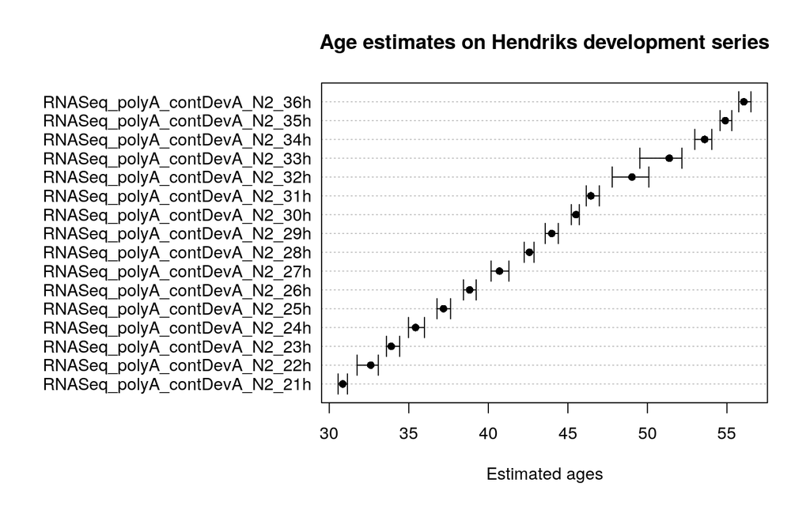

```r
plot(ae_hendriks, main="Age estimates on Hendriks development series")
```

The `ae` object also holds the correlation scores of the samples against the reference series and their 95% intervals accross the bootstrap. You can also plot these correlation profiles with `plot_cor.ae()`

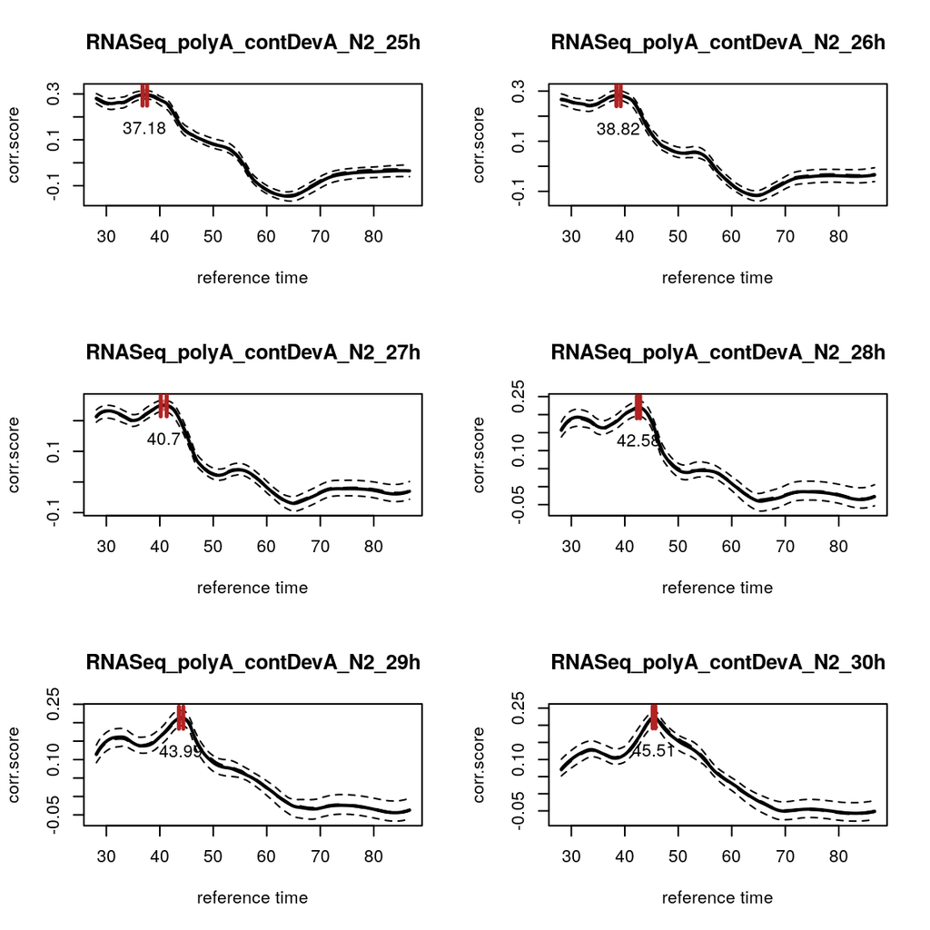

```r
par(mfrow=c(3,2))
plot_cor.ae(ae_hendriks, subset = 5:10)
```

If we zoom on these plots, we’ll see that the 95 % interval is represented for both the estimate (red bars) and the correlation scores (black dotted lines). The global estimate is also given below the interval.

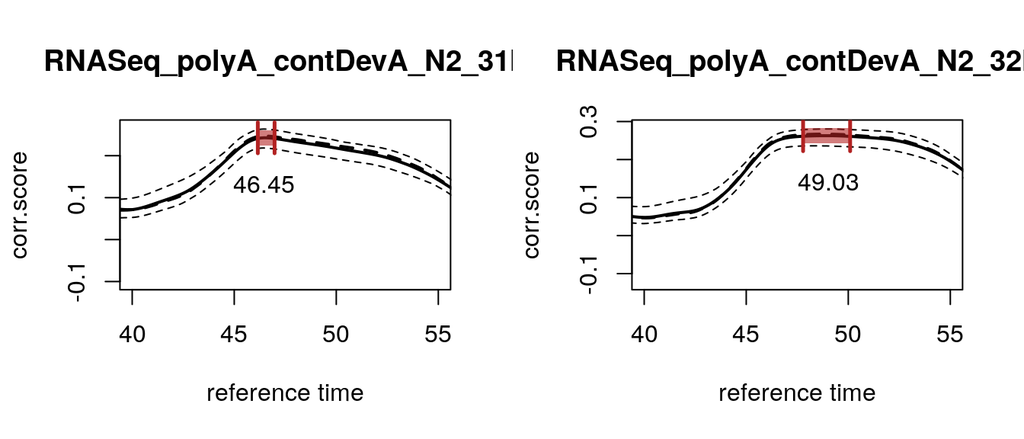

```r
par(mfrow=c(1,2))
plot_cor.ae(ae_hendriks, subset = 11:12, xlim=c(40,55))
```

## If the bootstrap estimates ‘jump around’

In some cases, two different developmental stages can both be very closely correlated with a sample. This has the consequence that, with some random gene subsets, the bootstrap estimates will ‘jump’ between the two and the confidence interval will be quite large and uneven (the global estimate will stick to one edge of it).

This can be a consequence of different problems :

- If the sample is bulk, it may have worms of an unexpected developmental stage contaminating it
- The overlapping gene set between the sample and the reference may be missing key gene groups necessary to distinguish between larval states ; unlikely, unless
- The overlapping gene set is very small (less than a few thousand), which necessarily means that
- The boostrap gene subset size is too small

We can simulate the last case with our previous dataset by messing with the `bootstrap.set_size` parameter.

```r
set.seed(10) # for reproducible results (get the same random gene subsets each time)

ae_hend_boot <- estimate.worm_age(samp = geno.hendriks[, 1:3], # only take 3 samples for the example
                                  refdata = ref_larval$interpol.gene_expr,
                                  ref.time_series = ref_larval$time.series,
                                  bootstrap.set_size = 500, # make the bt subset size very small
                                  bootstrap.n = 100) # do more bt steps to be sure to get the issue
```

```
##                 nb.genes
## refdata            12168
## samp               19673
## intersect.genes    12164
## Performing age estimation...
## Bootstrapping...
##  Building gene subsets...
##  Computing correlations...
##  Performing age estimation...
## Computing summary statistics...
```

The samples with this problem are detected through the `IC.imbalance` criterion mentioned above (when >5), and marked in the summary by an asterisk.

```r
summary(ae_hend_boot)
```

```
##
## Span of samples : 3.05
## Range of samples :  [ 30.848 , 33.898 ]
## -----------------------------------------------------------
##                              age.estimate   2.5%  97.5%
## RNASeq_polyA_contDevA_N2_21h       30.848 29.672 42.346 *
## RNASeq_polyA_contDevA_N2_22h       32.608 31.024  41.95 *
## RNASeq_polyA_contDevA_N2_23h       33.898 32.197 35.012
## -----------------------------------------------------------
##  * : Warning, estimate jumps around on bootstrap
```

We can also show the bootstrap estimates as swarms on the `ae` plot, allowing us to see their distribution along the confidence interval.

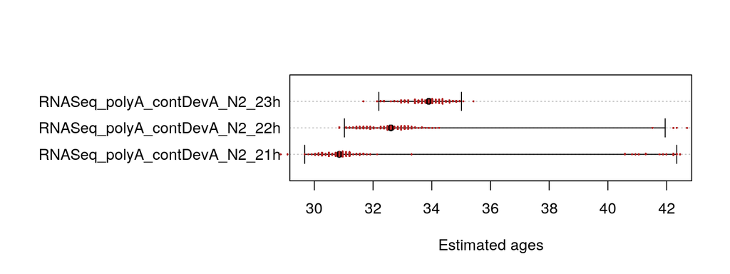

```r
plot(ae_hend_boot, show.boot_estimates = TRUE, col.b = 'firebrick')
```

You’ll notice that most of our bootstrap estimates are still around the global estimate, and that a few have gone astray 10 hours further (*ie* on the next molt/larval state, in our case). If you see this, increasing the bootstrap gene subset size should solve the issue (default is $n/3$, with $n$ the number of overlapping genes between sample and reference).

If you notice the bootstrap estimates are spread half and half, even with a large number of bootstrap steps (>=100), you may want to consider using a prior for these particular samples. Be warned that the prior have a significant impact on the estimate.

## Using a prior

In some cases, it may be appropriate to use a prior, helping with the estimate. The way priors work in the `estimate.worm_age()` function is that the parameters for the prior (gaussian) distribution are given (for each sample) and the correlation peaks are ranked according to the prior’s density at their respective times.

**This implies that with a prior which is completely off, the estimate will also be wrong ; use with care.**

# References

Hendriks, Gert-Jan, Dimos Gaidatzis, Florian Aeschimann, and Helge Großhans. 2014. “Extensive Oscillatory Gene Expression During c. Elegans Larval Development.” *Molecular Cell* 53 (3). Elsevier: 380–92.